# Coursework Output 2

*Instructions*: In this coursework, you will show your domain of the data related Python skills required for business analytics. To do so, you will use packages such as *numpy* and *matplotlib*.

## Importing and Visualising a Dataset in Python

Each student will be assigned a different dataset in a *comma separated value* (*.csv*) format. The main goal is to import such dataset into Python so that you can wrangle and visualise the data in better ways. This will allow you to get your own conclusions and start building up knowledge regarding on how you could potentially learn from data to predict or classify future instances.

You must create a program which allows you to select from the following options:

1. Import and print your dataset into Python as a numpy array.
2. Query and print an instance of the dataset by row number or by id (i.e. first column of the table).
3. Create a "reduced" dataset (i.e. with less columns) by indicating a list of column names to bring upon this newly created dataset.
4. Plot the dataset by means of a scatterplot which relates two columns specified by the user. The plot has to show the $x$ and $y$ axis labels as the chosen columns, and use the *target/class* column (i.e. the last one) as the colour variable.
5. Exit the program.

## Additional Considerations

- The program has to check that every input is valid.
- No option (except for exit) can be executed until option 1 is executed first.

## Submission Instructions

- Once that you have finished your program, run all cells and run the main program cell using the following sequence of options: 0(wrong option),2(has to fail),1,2(by row index),2(by row name),3,4,5.
- Then, without clearing the kernel, generate a html **OR** pdf file from the Jupyter notebook.
- Clear the Jupyter notebook kernel, then name both the Jupyter notebook and the html/pdf files with your id number and submit them to the corresponding Moodle's dropbox before **12th December, 2019**.

```python
!pip install pillow
!pip install matplotlib
!pip install scikit-image
!pip install scikit-learn
```

```python
### Use this cell to import all necessary packages
from PIL import Image
import numpy as np
import matplotlib.pyplot as plt
import pandas as pd
import csv
from sklearn import datasets
from sklearn.linear_model import LinearRegression
pd.set_option('display.max_rows', 1000)
```

```python
## Use this cell to define the function corresponding to OPTION 1
def option1(filename):
    '''With this function you import the dataset into a numpy array.'''
    data = pd.read_csv(filename)
    #pd.read_csv('countries.csv')
        #return pd.read_csv('countries.csv')
    return data
#option1('countries.csv')
```

```python
## Use this cell to define the function corresponding to OPTION 2
def option2(data, rowmethod, rownumber):
    '''This function queries and prints a row of the dataset (by row number or id).'''
#print('Select the row number  to query')
#row = input(int)
#x=0
#while 0<row>142:
    #data=pd.read_csv(filename)
    #data = filename

    if rowmethod == 1:
        row = data.loc[rownumber]
        print(row)
    elif rowmethod == 2:
        row = data.loc[data['country id'] == rownumber]
        print(row)
#data = option1('countries.csv')
#option2(data,2,107)
```

```python
## Use this cell to define the function corresponding to OPTION 3
def option3(columnname, data, newdata):
    '''This function creates a new dataset by indicating which columns to include.'''

    #data = pd.read_csv(filename)
    data.head()
    #newdata = data[columnname].values
    newdata1=data[columnname].values
    newdata.append(newdata1)
#b=data['continent'].values
#data[['population','continent']]
    return newdata

#option3('country id','countries.csv')
```

```python
# Use this cell to define the function corresponding to OPTION 4
def option4(xaxis,yaxis,target):
    '''This function visualises the dataset using a scatterplot.'''
#data.plot(kind='scatter', x='gdp_per_capita', y='population', c='continent', cmap='gnuplot2', title= 'GDP vs Population')
    data.plot(kind='scatter', x=xaxis, y=yaxis, c=target, cmap='gnuplot2', title= xaxis+' vs '+yaxis)

#data.plot.scatter(x='gdp_per_capita', y='population', c='continent')
    plt.show()

#option4('gdp_per_capita','population','continent')
```

```python
## Use this cell to create the "main" part of your program
## Use this cell to create the "main" part of your program
print('Welcome to Sana Hayee AND 0917966 business case.')

options = []
newdata = []

x = True

while x:
    print('Welcome to my menu. Select an option (1,2,3,4,5):')
    x = input()
    options.append(x)

    if x == '1':
        data = option1('countries.csv')
        #option2(data,2,107)
        print(data)
        print ('Dataset has been imported!')
    elif x == '2':
        if '1' in options:

            print('Select 1 to query by row number or 2 to query by row name:')
            rowmethod = int(input())
            while rowmethod not in [1,2]:

                    print('Option not valid')
                    print('Select 1 to query by row number or 2 to query by row name:')
                    rowmethod = int(input())
                    continue

            if rowmethod == 1:
                print('Select the row number to query (indexes start in 0):')
                rownumber = int(input())
                while rownumber < 0 or rownumber > len(data):

                    print('Option not valid')
                    print('Select the row number to query (indexes start in 0):')
                    rownumber = int(input())
                    continue

            elif rowmethod == 2:
                print('Select the row number to query:')
                rownumber = int(input())
                while rownumber not in data['country id'].values:

                    print('Option not valid')
                    print('Select the row number to query:')
                    rownumber = int(input())
                    continue

            rowdata = option2 (data, rowmethod, rownumber)
            print(rowdata)
        else:
            print('The first option to be selected shall be 1. Please try again')
    elif x == '3':
        if '1' in options:
            y = True
            while y:
                print('Indicate a column to include:')
                print(data.columns)
                columnname = input()
                if columnname not in data:
                    print('Column does not exists')
                    continue


                #columnname = 'population'
                option3(columnname,data,newdata)
                print('Do you want to indicate another column? (Y/N)')
                yn = input()
                if yn == 'N' or yn == 'n':
                    print(newdata)
                    break


        else:
            print('The first option to be selected shall be 1. Please try again')
        # (students, marks) = option3()
    elif x == '4':
        if '1' in options:
            z = True
            xaxis = ''
            yaxis = ''
            while z:
                print('Select the variable to use as x axis:')
                print(data.columns)
                xaxis=input()
                while xaxis not in data:
                    print('Column does not exists')
                    print('Select the variable to use as x axis:')
                    print(data.columns)
                    xaxis=input()
                    continue

                print('Select the variable to use as y axis:')
                print(data.columns)
                yaxis=input()
                while yaxis not in data:
                    print('Column does not exists')
                    print('Select the variable to use as y axis:')
                    print(data.columns)
                    yaxis=input()
                    continue

                print('Select the variable to use as target:')
                print(data.columns)
                target=input()
                while target not in data:
                    print('Column does not exists')
                    print('Select the variable to use as target:')
                    print(data.columns)
                    target=input()
                    continue

                option4(xaxis,yaxis,target)
                break
        else:
            print('The first option to be selected shall be 1. Please try again')
    elif x == '5':


        break
    else:
        print('Wrong option. Please try again.')
```

```
Welcome to Sana Hayee AND 0917966 business case.
Welcome to my menu. Select an option (1,2,3,4,5):
ijij
Wrong option. Please try again.
Welcome to my menu. Select an option (1,2,3,4,5):
9999
Wrong option. Please try again.
Welcome to my menu. Select an option (1,2,3,4,5):
2
The first option to be selected shall be 1. Please try again
Welcome to my menu. Select an option (1,2,3,4,5):
1
     country id  population  life_expectancy  gdp_per_capita  continent
0            11    31889923           43.828      974.580338          1
1            23     3600523           76.423     5937.029526          3
```

[output cut: 148 more lines]

```
---------------------------------------------------------------------------
ValueError                                Traceback (most recent call last)
<ipython-input-8-d1e34d6b0e64> in <module>()
     27                     print('Option not valid')
     28                     print('Select 1 to query by row number or 2 to query by row name:')
---> 29                     rowmethod = int(input())
     30                     continue
     31

ValueError: invalid literal for int() with base 10: 'dxdf'
```

**At this stage you didn't check that the input has to be a number, and thus the code crashed!**

```python
## Use this cell to create the "main" part of your program
## Use this cell to create the "main" part of your program
print('Welcome to Sana Hayee AND 0917966 business case.')

options = []
newdata = []

x = True

while x:
    print('Welcome to my menu. Select an option (1,2,3,4,5):')
    x = input()
    options.append(x)

    if x == '1':
        data = option1('countries.csv')
        #option2(data,2,107)
        print(data)
        print ('Dataset has been imported!')
    elif x == '2':
        if '1' in options:

            print('Select 1 to query by row number or 2 to query by row name:')
            rowmethod = int(input())
            while rowmethod not in [1,2]:

                    print('Option not valid')
                    print('Select 1 to query by row number or 2 to query by row name:')
                    rowmethod = int(input())
                    continue

            if rowmethod == 1:
                print('Select the row number to query (indexes start in 0):')
                rownumber = int(input())
                while rownumber < 0 or rownumber > len(data):

                    print('Option not valid')
                    print('Select the row number to query (indexes start in 0):')
                    rownumber = int(input())
                    continue

            elif rowmethod == 2:
                print('Select the row number to query:')
                rownumber = int(input())
                while rownumber not in data['country id'].values:

                    print('Option not valid')
                    print('Select the row number to query:')
                    rownumber = int(input())
                    continue

            rowdata = option2 (data, rowmethod, rownumber)
            print(rowdata)
        else:
            print('The first option to be selected shall be 1. Please try again')
    elif x == '3':
        if '1' in options:
            y = True
            while y:
                print('Indicate a column to include:')
                print(data.columns)
                columnname = input()
                if columnname not in data:
                    print('Column does not exists')
                    continue


                #columnname = 'population'
                option3(columnname,data,newdata)
                print('Do you want to indicate another column? (Y/N)')
                yn = input()
                if yn == 'N' or yn == 'n':
                    print(newdata)
                    break


        else:
            print('The first option to be selected shall be 1. Please try again')
        # (students, marks) = option3()
    elif x == '4':
        if '1' in options:
            z = True
            xaxis = ''
            yaxis = ''
            while z:
                print('Select the variable to use as x axis:')
                print(data.columns)
                xaxis=input()
                while xaxis not in data:
                    print('Column does not exists')
                    print('Select the variable to use as x axis:')
                    print(data.columns)
                    xaxis=input()
                    continue

                print('Select the variable to use as y axis:')
                print(data.columns)
                yaxis=input()
                while yaxis not in data:
                    print('Column does not exists')
                    print('Select the variable to use as y axis:')
                    print(data.columns)
                    yaxis=input()
                    continue

                print('Select the variable to use as target:')
                print(data.columns)
                target=input()
                while target not in data:
                    print('Column does not exists')
                    print('Select the variable to use as target:')
                    print(data.columns)
                    target=input()
                    continue

                option4(xaxis,yaxis,target)
                break
        else:
            print('The first option to be selected shall be 1. Please try again')
    elif x == '5':


        break
    else:
        print('Wrong option. Please try again.')
```

```
Welcome to Sana Hayee AND 0917966 business case.
Welcome to my menu. Select an option (1,2,3,4,5):
1
     country id  population  life_expectancy  gdp_per_capita  continent
0            11    31889923           43.828      974.580338          1
1            23     3600523           76.423     5937.029526          3
2            35    33333216           72.301     6223.367465          4
3            47    12420476           42.731     4797.231267          4
4            59    40301927           75.320    12779.379640          2
5            71    20434176           81.235    34435.367440          5
6            83     8199783           79.829    36126.492700          3
7            95      708573           75.635    29796.048340          1
8           107   150448339           64.062     1391.253792          1
9           119    10392226           79.441    33692.605080          3
10          131     8078314           56.728     1441.284873          4
```

[output cut: 141 more lines]

[output not shown]

**Here I queried for row 142 and the code crashed**

```python
## Use this cell to create the "main" part of your program
## Use this cell to create the "main" part of your program
print('Welcome to Sana Hayee AND 0917966 business case.')

options = []
newdata = []

x = True

while x:
    print('Welcome to my menu. Select an option (1,2,3,4,5):')
    x = input()
    options.append(x)

    if x == '1':
        data = option1('countries.csv')
        #option2(data,2,107)
        print(data)
        print ('Dataset has been imported!')
    elif x == '2':
        if '1' in options:

            print('Select 1 to query by row number or 2 to query by row name:')
            rowmethod = int(input())
            while rowmethod not in [1,2]:

                    print('Option not valid')
                    print('Select 1 to query by row number or 2 to query by row name:')
                    rowmethod = int(input())
                    continue

            if rowmethod == 1:
                print('Select the row number to query (indexes start in 0):')
                rownumber = int(input())
                while rownumber < 0 or rownumber > len(data):

                    print('Option not valid')
                    print('Select the row number to query (indexes start in 0):')
                    rownumber = int(input())
                    continue

            elif rowmethod == 2:
                print('Select the row number to query:')
                rownumber = int(input())
                while rownumber not in data['country id'].values:

                    print('Option not valid')
                    print('Select the row number to query:')
                    rownumber = int(input())
                    continue

            rowdata = option2 (data, rowmethod, rownumber)
            print(rowdata)
        else:
            print('The first option to be selected shall be 1. Please try again')
    elif x == '3':
        if '1' in options:
            y = True
            while y:
                print('Indicate a column to include:')
                print(data.columns)
                columnname = input()
                if columnname not in data:
                    print('Column does not exists')
                    continue


                #columnname = 'population'
                option3(columnname,data,newdata)
                print('Do you want to indicate another column? (Y/N)')
                yn = input()
                if yn == 'N' or yn == 'n':
                    print(newdata)
                    break


        else:
            print('The first option to be selected shall be 1. Please try again')
        # (students, marks) = option3()
    elif x == '4':
        if '1' in options:
            z = True
            xaxis = ''
            yaxis = ''
            while z:
                print('Select the variable to use as x axis:')
                print(data.columns)
                xaxis=input()
                while xaxis not in data:
                    print('Column does not exists')
                    print('Select the variable to use as x axis:')
                    print(data.columns)
                    xaxis=input()
                    continue

                print('Select the variable to use as y axis:')
                print(data.columns)
                yaxis=input()
                while yaxis not in data:
                    print('Column does not exists')
                    print('Select the variable to use as y axis:')
                    print(data.columns)
                    yaxis=input()
                    continue

                print('Select the variable to use as target:')
                print(data.columns)
                target=input()
                while target not in data:
                    print('Column does not exists')
                    print('Select the variable to use as target:')
                    print(data.columns)
                    target=input()
                    continue

                option4(xaxis,yaxis,target)
                break
        else:
            print('The first option to be selected shall be 1. Please try again')
    elif x == '5':


        break
    else:
        print('Wrong option. Please try again.')
```

```
Welcome to Sana Hayee AND 0917966 business case.
Welcome to my menu. Select an option (1,2,3,4,5):
1
     country id  population  life_expectancy  gdp_per_capita  continent
0            11    31889923           43.828      974.580338          1
1            23     3600523           76.423     5937.029526          3
2            35    33333216           72.301     6223.367465          4
3            47    12420476           42.731     4797.231267          4
4            59    40301927           75.320    12779.379640          2
5            71    20434176           81.235    34435.367440          5
6            83     8199783           79.829    36126.492700          3
7            95      708573           75.635    29796.048340          1
8           107   150448339           64.062     1391.253792          1
9           119    10392226           79.441    33692.605080          3
10          131     8078314           56.728     1441.284873          4
```

[output cut: 151 more lines]

```
---------------------------------------------------------------------------
ValueError                                Traceback (most recent call last)
<ipython-input-10-d1e34d6b0e64> in <module>()
     42             elif rowmethod == 2:
     43                 print('Select the row number to query:')
---> 44                 rownumber = int(input())
     45                 while rownumber not in data['country id'].values:
     46

ValueError: invalid literal for int() with base 10: 'potato'
```

**Once again, you didn't check if the entry was an integer and thus your code crashed!**

```python
## Use this cell to create the "main" part of your program
## Use this cell to create the "main" part of your program
print('Welcome to Sana Hayee AND 0917966 business case.')

options = []
newdata = []

x = True

while x:
    print('Welcome to my menu. Select an option (1,2,3,4,5):')
    x = input()
    options.append(x)

    if x == '1':
        data = option1('countries.csv')
        #option2(data,2,107)
        print(data)
        print ('Dataset has been imported!')
    elif x == '2':
        if '1' in options:

            print('Select 1 to query by row number or 2 to query by row name:')
            rowmethod = int(input())
            while rowmethod not in [1,2]:

                    print('Option not valid')
                    print('Select 1 to query by row number or 2 to query by row name:')
                    rowmethod = int(input())
                    continue

            if rowmethod == 1:
                print('Select the row number to query (indexes start in 0):')
                rownumber = int(input())
                while rownumber < 0 or rownumber > len(data):

                    print('Option not valid')
                    print('Select the row number to query (indexes start in 0):')
                    rownumber = int(input())
                    continue

            elif rowmethod == 2:
                print('Select the row number to query:')
                rownumber = int(input())
                while rownumber not in data['country id'].values:

                    print('Option not valid')
                    print('Select the row number to query:')
                    rownumber = int(input())
                    continue

            rowdata = option2 (data, rowmethod, rownumber)
            print(rowdata)
        else:
            print('The first option to be selected shall be 1. Please try again')
    elif x == '3':
        if '1' in options:
            y = True
            while y:
                print('Indicate a column to include:')
                print(data.columns)
                columnname = input()
                if columnname not in data:
                    print('Column does not exists')
                    continue


                #columnname = 'population'
                option3(columnname,data,newdata)
                print('Do you want to indicate another column? (Y/N)')
                yn = input()
                if yn == 'N' or yn == 'n':
                    print(newdata)
                    break


        else:
            print('The first option to be selected shall be 1. Please try again')
        # (students, marks) = option3()
    elif x == '4':
        if '1' in options:
            z = True
            xaxis = ''
            yaxis = ''
            while z:
                print('Select the variable to use as x axis:')
                print(data.columns)
                xaxis=input()
                while xaxis not in data:
                    print('Column does not exists')
                    print('Select the variable to use as x axis:')
                    print(data.columns)
                    xaxis=input()
                    continue

                print('Select the variable to use as y axis:')
                print(data.columns)
                yaxis=input()
                while yaxis not in data:
                    print('Column does not exists')
                    print('Select the variable to use as y axis:')
                    print(data.columns)
                    yaxis=input()
                    continue

                print('Select the variable to use as target:')
                print(data.columns)
                target=input()
                while target not in data:
                    print('Column does not exists')
                    print('Select the variable to use as target:')
                    print(data.columns)
                    target=input()
                    continue

                option4(xaxis,yaxis,target)
                break
        else:
            print('The first option to be selected shall be 1. Please try again')
    elif x == '5':


        break
    else:
        print('Wrong option. Please try again.')
```

```
Welcome to Sana Hayee AND 0917966 business case.
Welcome to my menu. Select an option (1,2,3,4,5):
1
     country id  population  life_expectancy  gdp_per_capita  continent
0            11    31889923           43.828      974.580338          1
1            23     3600523           76.423     5937.029526          3
2            35    33333216           72.301     6223.367465          4
3            47    12420476           42.731     4797.231267          4
4            59    40301927           75.320    12779.379640          2
5            71    20434176           81.235    34435.367440          5
6            83     8199783           79.829    36126.492700          3
7            95      708573           75.635    29796.048340          1
8           107   150448339           64.062     1391.253792          1
9           119    10392226           79.441    33692.605080          3
10          131     8078314           56.728     1441.284873          4
```

[output cut: 230 more lines]

```python
print(newdata,type(newdata))
```

```
[array([  11,   23,   35,   47,   59,   71,   83,   95,  107,  119,  131,
        143,  155,  167,  179,  191,  203,  215,  227,  239,  251,  263,
        275,  287,  299,  311,  323,  335,  347,  359,  371,  383,  395,
        407,  419,  431,  443,  455,  467,  479,  491,  503,  515,  527,
        539,  551,  563,  575,  587,  599,  611,  623,  635,  647,  659,
        671,  683,  695,  707,  719,  731,  743,  755,  767,  779,  791,
        803,  815,  827,  839,  851,  863,  875,  887,  899,  911,  923,
        935,  947,  959,  971,  983,  995, 1007, 1019, 1031, 1043, 1055,
       1067, 1079, 1091, 1103, 1115, 1127, 1139, 1151, 1163, 1175, 1187,
       1199, 1211, 1223, 1235, 1247, 1259, 1271, 1283, 1295, 1307, 1319,
       1331, 1343, 1355, 1367, 1379, 1391, 1403, 1415, 1427, 1439, 1451,
       1463, 1475, 1487, 1499, 1511, 1523, 1535, 1547, 1559, 1571, 1583,
       1595, 1607, 1619, 1631, 1643, 1655, 1667, 1679, 1691, 1703],
      dtype=int64), array([  11,   23,   35,   47,   59,   71,   83,   95,  107,  119,  131,
        143,  155,  167,  179,  191,  203,  215,  227,  239,  251,  263,
```

[output cut: 25 more lines]

**The two cells above imply three problems:** **1. If I input `potato` instead of yes, the program still asks me for more columns.** **2. If I indicate a column that I indicated before, then the program allows me to include it in the `newdata` variable.** **3. The newdata structure that you created is a list, which is not effective in case that we want to continue using this new structure.**

```
Welcome to Sana Hayee AND 0917966 business case.
Welcome to my menu. Select an option (1,2,3,4,5):
1
     country id  population  life_expectancy  gdp_per_capita  continent
0            11    31889923           43.828      974.580338          1
1            23     3600523           76.423     5937.029526          3
2            35    33333216           72.301     6223.367465          4
3            47    12420476           42.731     4797.231267          4
4            59    40301927           75.320    12779.379640          2
5            71    20434176           81.235    34435.367440          5
6            83     8199783           79.829    36126.492700          3
7            95      708573           75.635    29796.048340          1
8           107   150448339           64.062     1391.253792          1
9           119    10392226           79.441    33692.605080          3
10          131     8078314           56.728     1441.284873          4
```

[output cut: 155 more lines]

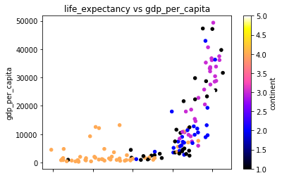

```
Welcome to my menu. Select an option (1,2,3,4,5):
5
```

```python
## Use this cell to create the "main" part of your program
## Use this cell to create the "main" part of your program
print('Welcome to Sana Hayee AND 0917966 business case.')

options = []
newdata = []

x = True

while x:
    print('Welcome to my menu. Select an option (1,2,3,4,5):')
    x = input()
    options.append(x)

    if x == '1':
        data = option1('countries.csv')
        #option2(data,2,107)
        print(data)
        print ('Dataset has been imported!')
    elif x == '2':
        if '1' in options:

            print('Select 1 to query by row number or 2 to query by row name:')
            rowmethod = int(input())
            while rowmethod not in [1,2]:

                    print('Option not valid')
                    print('Select 1 to query by row number or 2 to query by row name:')
                    rowmethod = int(input())
                    continue

            if rowmethod == 1:
                print('Select the row number to query (indexes start in 0):')
                rownumber = int(input())
                while rownumber < 0 or rownumber > len(data):

                    print('Option not valid')
                    print('Select the row number to query (indexes start in 0):')
                    rownumber = int(input())
                    continue

            elif rowmethod == 2:
                print('Select the row number to query:')
                rownumber = int(input())
                while rownumber not in data['country id'].values:

                    print('Option not valid')
                    print('Select the row number to query:')
                    rownumber = int(input())
                    continue

            rowdata = option2 (data, rowmethod, rownumber)
            print(rowdata)
        else:
            print('The first option to be selected shall be 1. Please try again')
    elif x == '3':
        if '1' in options:
            y = True
            while y:
                print('Indicate a column to include:')
                print(data.columns)
                columnname = input()
                if columnname not in data:
                    print('Column does not exists')
                    continue


                #columnname = 'population'
                option3(columnname,data,newdata)
                print('Do you want to indicate another column? (Y/N)')
                yn = input()
                if yn == 'N' or yn == 'n':
                    print(newdata)
                    break


        else:
            print('The first option to be selected shall be 1. Please try again')
        # (students, marks) = option3()
    elif x == '4':
        if '1' in options:
            z = True
            xaxis = ''
            yaxis = ''
            while z:
                print('Select the variable to use as x axis:')
                print(data.columns)
                xaxis=input()
                while xaxis not in data:
                    print('Column does not exists')
                    print('Select the variable to use as x axis:')
                    print(data.columns)
                    xaxis=input()
                    continue

                print('Select the variable to use as y axis:')
                print(data.columns)
                yaxis=input()
                while yaxis not in data:
                    print('Column does not exists')
                    print('Select the variable to use as y axis:')
                    print(data.columns)
                    yaxis=input()
                    continue

                print('Select the variable to use as target:')
                print(data.columns)
                target=input()
                while target not in data:
                    print('Column does not exists')
                    print('Select the variable to use as target:')
                    print(data.columns)
                    target=input()
                    continue

                option4(xaxis,yaxis,target)
                break
        else:
            print('The first option to be selected shall be 1. Please try again')
    elif x == '5':


        break
    else:
        print('Wrong option. Please try again.')
```

**The chart is missing the x-axis label**

## Questions

Please answer the following questions to appraise your level of engagement with the content of the course. Use the Markdown cell corresponding to each question to write your answers.

1. Is there any other data structure or module in Python (besides *numpy*) which would allow you to import a *.csv* file in a more practical and manageable way? Use a code cell to support your answer.

**ANSWER:**

## Use this cell to import your dataset with a data structure other than numpy

option1

Pandas can be used to import dataset with a data structure other than numpy. Following steps can be used to import and run. 1) import Pandas as pd 2) capture the file path. File path contains file name and file extention 3) run the code pd.read_csv 4) selecting subset of coloumns (you can select exact coloumns names to get an output). If specified coloumn name is different from csv file coloumn name. It will give NaN values message.

option2

Below cell also shows how to import data as a numpy.

```python
#Option 1
#importing data with pandas
pd.read_csv('countries.csv')
```

|  | country id | population | life_expectancy | gdp_per_capita | continent |
| --- | --- | --- | --- | --- | --- |
| 0 | 11 | 31889923 | 43.828 | 974.580338 | 1 |
| 1 | 23 | 3600523 | 76.423 | 5937.029526 | 3 |
| 2 | 35 | 33333216 | 72.301 | 6223.367465 | 4 |
| 3 | 47 | 12420476 | 42.731 | 4797.231267 | 4 |
| 4 | 59 | 40301927 | 75.320 | 12779.379640 | 2 |
| 5 | 71 | 20434176 | 81.235 | 34435.367440 | 5 |
| 6 | 83 | 8199783 | 79.829 | 36126.492700 | 3 |
| 7 | 95 | 708573 | 75.635 | 29796.048340 | 1 |
| 8 | 107 | 150448339 | 64.062 | 1391.253792 | 1 |
| 9 | 119 | 10392226 | 79.441 | 33692.605080 | 3 |
| 10 | 131 | 8078314 | 56.728 | 1441.284873 | 4 |
| 11 | 143 | 9119152 | 65.554 | 3822.137084 | 2 |
| 12 | 155 | 4552198 | 74.852 | 7446.298803 | 3 |
| 13 | 167 | 1639131 | 50.728 | 12569.851770 | 4 |
| 14 | 179 | 190010647 | 72.390 | 9065.800825 | 2 |
| 15 | 191 | 7322858 | 73.005 | 10680.792820 | 3 |
| 16 | 203 | 14326203 | 52.295 | 1217.032994 | 4 |
| 17 | 215 | 8390505 | 49.580 | 430.070692 | 4 |
| 18 | 227 | 14131858 | 59.723 | 1713.778686 | 1 |
| 19 | 239 | 17696293 | 50.430 | 2042.095240 | 4 |
| 20 | 251 | 33390141 | 80.653 | 36319.235010 | 2 |
| 21 | 263 | 4369038 | 44.741 | 706.016537 | 4 |
| 22 | 275 | 10238807 | 50.651 | 1704.063724 | 4 |
| 23 | 287 | 16284741 | 78.553 | 13171.638850 | 2 |
| 24 | 299 | 1318683096 | 72.961 | 4959.114854 | 1 |
| 25 | 311 | 44227550 | 72.889 | 7006.580419 | 2 |
| 26 | 323 | 710960 | 65.152 | 986.147879 | 4 |
| 27 | 335 | 64606759 | 46.462 | 277.551859 | 4 |
| 28 | 347 | 3800610 | 55.322 | 3632.557798 | 4 |
| 29 | 359 | 4133884 | 78.782 | 9645.061420 | 2 |

[output cut: 112 more lines]

```python
#Option 2
#importing data in numpy
countries=np.genfromtxt("countries.csv", delimiter =",", names = True, skip_header=0)
print(countries.dtype.names)
print(countries)
```

```
('country_id', 'population', 'life_expectancy', 'gdp_per_capita', 'continent')
[(  11., 3.18899230e+07, 43.828,   974.5803384, 1.)
 (  23., 3.60052300e+06, 76.423,  5937.029526 , 3.)
 (  35., 3.33332160e+07, 72.301,  6223.367465 , 4.)
 (  47., 1.24204760e+07, 42.731,  4797.231267 , 4.)
 (  59., 4.03019270e+07, 75.32 , 12779.37964  , 2.)
 (  71., 2.04341760e+07, 81.235, 34435.36744  , 5.)
 (  83., 8.19978300e+06, 79.829, 36126.4927   , 3.)
 (  95., 7.08573000e+05, 75.635, 29796.04834  , 1.)
 ( 107., 1.50448339e+08, 64.062,  1391.253792 , 1.)
 ( 119., 1.03922260e+07, 79.441, 33692.60508  , 3.)
 ( 131., 8.07831400e+06, 56.728,  1441.284873 , 4.)
 ( 143., 9.11915200e+06, 65.554,  3822.137084 , 2.)
 ( 155., 4.55219800e+06, 74.852,  7446.298803 , 3.)
 ( 167., 1.63913100e+06, 50.728, 12569.85177  , 4.)
 ( 179., 1.90010647e+08, 72.39 ,  9065.800825 , 2.)
 ( 191., 7.32285800e+06, 73.005, 10680.79282  , 3.)
 ( 203., 1.43262030e+07, 52.295,  1217.032994 , 4.)
 ( 215., 8.39050500e+06, 49.58 ,   430.0706916, 4.)
 ( 227., 1.41318580e+07, 59.723,  1713.778686 , 1.)
 ( 239., 1.76962930e+07, 50.43 ,  2042.09524  , 4.)
 ( 251., 3.33901410e+07, 80.653, 36319.23501  , 2.)
 ( 263., 4.36903800e+06, 44.741,   706.016537 , 4.)
 ( 275., 1.02388070e+07, 50.651,  1704.063724 , 4.)
 ( 287., 1.62847410e+07, 78.553, 13171.63885  , 2.)
 ( 299., 1.31868310e+09, 72.961,  4959.114854 , 1.)
 ( 311., 4.42275500e+07, 72.889,  7006.580419 , 2.)
 ( 323., 7.10960000e+05, 65.152,   986.1478792, 4.)
 ( 335., 6.46067590e+07, 46.462,   277.5518587, 4.)
 ( 347., 3.80061000e+06, 55.322,  3632.557798 , 4.)
 ( 359., 4.13388400e+06, 78.782,  9645.06142  , 2.)
 ( 371., 1.80134090e+07, 48.328,  1544.750112 , 4.)
 ( 383., 4.49331200e+06, 75.748, 14619.22272  , 3.)
 ( 395., 1.14169870e+07, 78.273,  8948.102923 , 2.)
 ( 407., 1.02287440e+07, 76.486, 22833.30851  , 3.)
 ( 419., 5.46812000e+06, 78.332, 35278.41874  , 3.)
 ( 431., 4.96374000e+05, 54.791,  2082.481567 , 4.)
 ( 443., 9.31962200e+06, 72.235,  6025.374752 , 2.)
 ( 455., 1.37556800e+07, 74.994,  6873.262326 , 2.)
 ( 467., 8.02645430e+07, 71.338,  5581.180998 , 4.)
```

[output cut: 88 more lines]

```
 (1535., 6.50681490e+07, 70.616,  7458.396327 , 1.)
 (1547., 5.70157900e+06, 58.42 ,   882.9699438, 4.)
 (1559., 1.05660800e+06, 69.819, 18008.50924  , 2.)
 (1571., 1.02761580e+07, 73.923,  7092.923025 , 4.)
 (1583., 7.11586470e+07, 71.777,  8458.276384 , 3.)
 (1595., 2.91703980e+07, 51.542,  1056.380121 , 4.)
 (1607., 6.07762380e+07, 79.425, 33203.26128  , 3.)
 (1619., 3.01139947e+08, 78.242, 42951.65309  , 2.)
 (1631., 3.44749600e+06, 76.384, 10611.46299  , 2.)
 (1643., 2.60846620e+07, 73.747, 11415.80569  , 2.)
 (1655., 8.52623560e+07, 74.249,  2441.576404 , 1.)
 (1667., 4.01833200e+06, 73.422,  3025.349798 , 1.)
 (1679., 2.22117430e+07, 62.698,  2280.769906 , 1.)
 (1691., 1.17460350e+07, 42.384,  1271.211593 , 4.)
 (1703., 1.23111430e+07, 43.487,   469.7092981, 4.)]
```

1. Using any of the two continuous variables of your dataset, using a cell code show an example of how a **linear regression** could be applied with your dataset to predict the values of future entries of data without target/class (you can implement linear regressions using existing Python modules). Moreover, discuss if there is any metric that can be used to decide which two variables are the most correlated.

**ANSWER:**

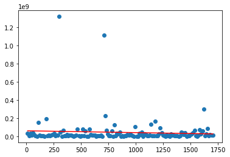

```python
## Use this cell to implement a linear regression between two variables
#data.plot(kind='scatter', x='gdp_per_capita', y='population', c='continent', cmap='gnuplot2', title= 'GDP vs Population')

data=pd.read_csv('countries.csv')
#values converts it into a numpy array
X = data.iloc[:, 0].values.reshape(-1, 1)
#-1 means that calculate the dimension of rows, but have 1 column
Y = data.iloc[:, 1].values.reshape(-1, 1)
linear_regressor = LinearRegression()
linear_regressor.fit(X, Y)
Y_pred = linear_regressor.predict(X)
plt.scatter(X, Y)
plt.plot(X, Y_pred, color='red')
plt.show()
```